# Da li je Ipsos svoje brojke mogao dobiti slučajno?

Poslednja predizborna anketa agencije Ipsos i zvanični rezultati parlamentarnih izbora 2026

Goran S. Milovanović, PhD

31. oktobar 2026.

# Ukratko

≈ 2 × 10<sup>−36</sup>

tolika je verovatnoća da slučajno izabran uzorak ljudi koji su glasali 25. oktobra 2026. dâ rezultat bar toliko udaljen od istine koliko su to bile objavljene brojke Ipsosa. Rečima: otprilike **jedan u petsto kvintilijardi** (broj 5 sa 35 nula). Taj broj je izračunat tačno, nabrajanjem svih 1.570.111.136 mogućih ishoda ankete, bez simulacije. U zavisnosti od načina računanja, brojka se kreće između 10<sup>−32</sup> i 10<sup>−36</sup>.

- Ipsos je 22. oktobra objavio: *Ujedinjena Srbija* **47,4%**, *Studentska lista* **40,0%**. Birači su 25. oktobra rekli: *Studentska lista* **53,0%**, *Ujedinjena Srbija* **39,0%**.
- Promašaj od 13,0 poena za jednu i 8,4 poena za drugu listu je oko **12 odnosno 8 puta veći** od uobičajene greške ankete te veličine.
- Od **dva miliona** simuliranih slučajnih anketa iz stvarnog biračkog tela, **nijedna** nije ni blizu Ipsosovog rezultata.
- Da bi Ipsosov rezultat bio obična „loša sreća“, oko **450.000 birača** moralo bi da pređe na *Studentsku listu* u tri dana između ankete i izbora.
- Druga objavljena anketa (NSPM) takođe je promašila u istom smeru, ali je Ipsosov rezultat oko 10<sup>24</sup> puta manje verovatan od njenog.

**Šta ovo znači:** slučajna greška uzorka *ne može* objasniti razliku. **Šta ovo ne znači:** ovaj dokument ne utvrđuje *zašto* je razlika nastala. Mogući razlozi su kasni preokret raspoloženja, drugačija izlaznost, ponašanje neodlučnih, metodološka pristrasnost ankete, ili to da objavljene brojke ne odražavaju ono što je anketa izmerila. Brojevi sami ne mogu da izaberu između tih objašnjenja, i ovaj dokument ne iznosi nikakvu tvrdnju o namerama.

# Šta se dogodilo

Tri dana pred izbore, 22. oktobra, agencija *Ipsos Strategic Marketing* objavila je svoju završnu procenu (anketa 20–22. oktobra, 3.624 ispitanika, naručilac: lista *Ujedinjena Srbija*). (Ovo je sažetak za javnost; tehnički izveštaj na engleskom sadrži potpunu analizu.) Zvanični rezultati Republičke izborne komisije (RIK), ovde prema stanju od 31. oktobar 2026, 11:00 (8.339 od 8.392 biračkih mesta, dakle još uvek preliminarni), izgledali su sasvim drugačije. Pitanje koje postavljamo: **da li je ispravno sprovedena slučajna anketa mogla da dâ Ipsosove brojke, ako je biračko telo izgledalo onako kako kažu rezultati?**

Tabela 1. Anketa i rezultat, u procentima svih ubačenih listića (Ipsos je u svoju procenu uključio pretpostavljenih 2,5% nevažećih, pa su osnove iste).

| Lista | Ipsos, 22. okt. | RIK, zvanično | Razlika (poeni) |
| --- | --- | --- | --- |
| Studentska lista | 40,0% | 53,0% | −13,0 |
| Ujedinjena Srbija | 47,4% | 39,0% | +8,4 |
| Manjinske liste (4 koje su ušle u Skupštinu) | 2,3% | 2,2% | +0,1 |
| Sve ostale liste i nevažeći listići | 10,3% | 5,8% | +4,5 |

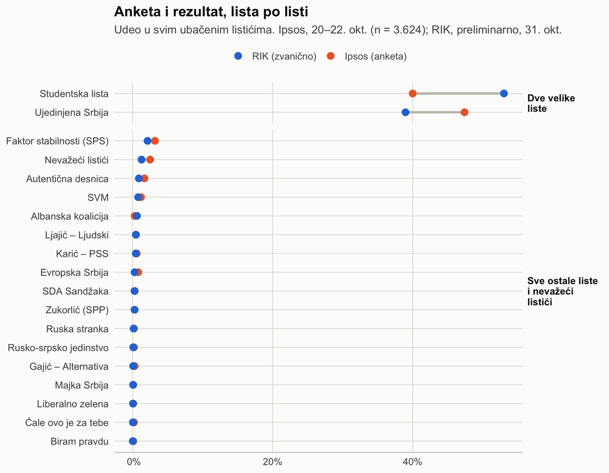

Slika 1. Gde je anketa smestila svaku listu (narandžasto) i gde su je birači smestili (plavo).

Za šesnaest malih lista i za nevažeće listiće Ipsos je bio blizu istine (greške do oko jednog poena, gotovo sve naviše). Ceo promašaj je u dve velike liste: *Studentska lista* **13,0 poena prenisko**, *Ujedinjena Srbija* **8,4 poena previsoko**.

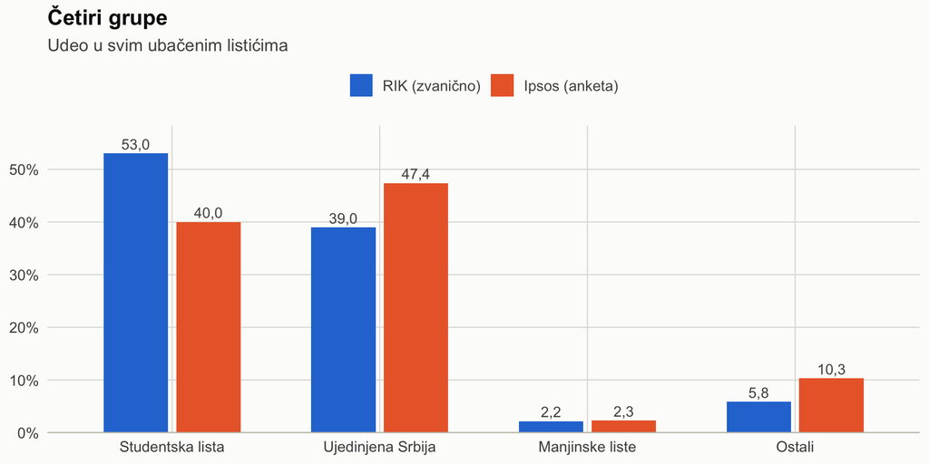

Slika 2. Isto poređenje u četiri grupe.

# Koliko anketa sme da pogreši?

Nijedna anketa nije savršeno tačna. Ako pitate 2.000 slučajno izabranih birača, nećete dobiti tačno 53,0% za listu koja stvarno ima 53,0%; dobićete možda 51,8% ili 54,3%. Pitanje zato nikad nije „da li je anketa pogrešila“, nego **„da li je pogrešila više nego što slučaj može da objasni“**. Koliko slučaj može da objasni, lako je proveriti: na računaru „sprovedemo“ sto hiljada zamišljenih anketa, svaku od po 2.000 slučajno izabranih ljudi iz stvarnog biračkog tela, i pogledamo šta dobijemo.

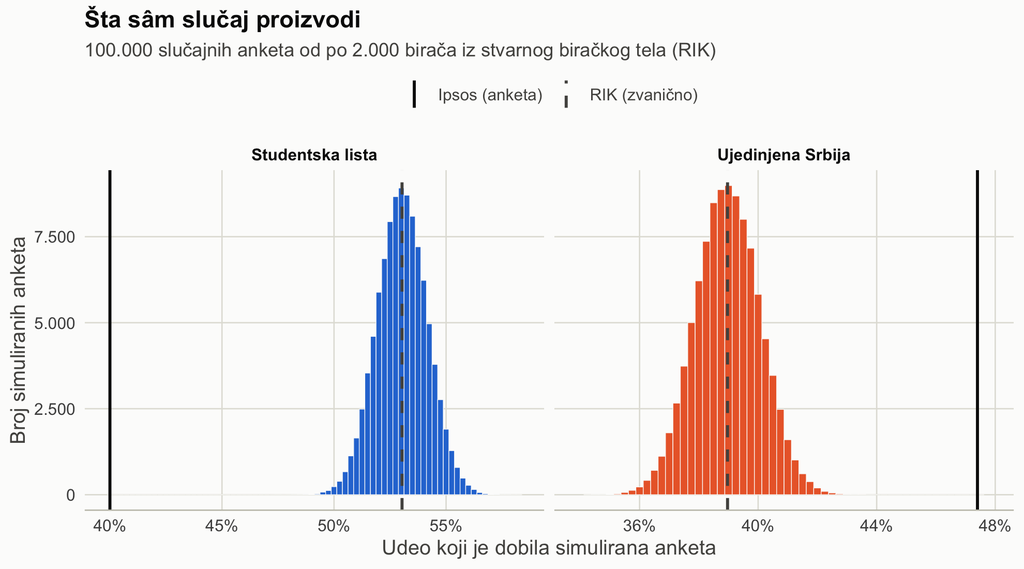

Slika 3. Rezultati 100.000 simuliranih slučajnih anketa od po 2.000 birača iz stvarnog biračkog tela. Isprekidana linija: istina. Puna crna linija: ono što je Ipsos objavio.

U sto hiljada pokušaja *Studentska lista* **nijednom** nije pala ispod 47,55%, a *Ujedinjena Srbija* nijednom nije prešla 43,75%. Ipsosovih 40,0% i 47,4% nisu „na repu“ ovih raspodela; oni su potpuno izvan svega što slučaj proizvodi.

# Koliko je veliki bio Ipsosov uzorak?

Što je uzorak veći, to je anketa preciznija i to je manja šansa za veliki promašaj. Ipsos navodi 3.624 ispitanika, ali su procenti za liste računati samo među onima koji su rekli za koga će glasati, a taj broj nije objavljen. Srećom, Ipsos je uz svaku listu objavio i „raspon greške“, a iz raspona greške može se izračunati koliki je uzorak agencija stvarno koristila. Rezultat: oko **2.110 ispitanika**. Mi koristimo taj, manji broj: to je izbor koji je **najpovoljniji za Ipsos**, jer manji uzorak znači više prostora za slučajnu grešku.

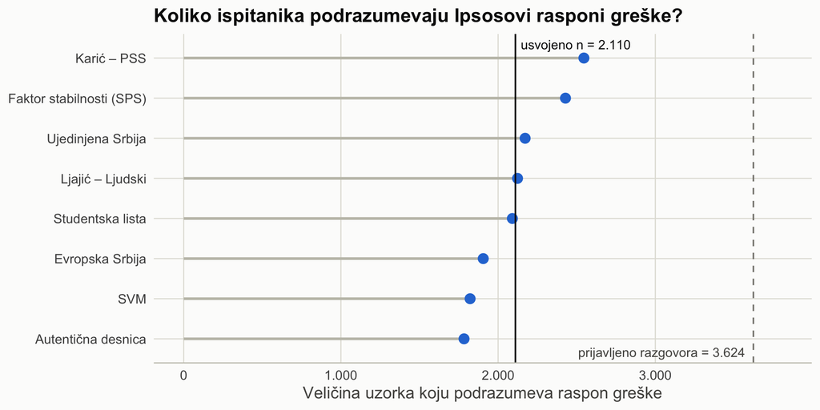

Slika 4. Veličina uzorka koju podrazumeva svaki od Ipsosovih objavljenih raspona greške. Puna linija: usvojenih 2.110. Isprekidana: 3.624 prijavljena razgovora.

# Kolika je verovatnoća Ipsosovog rezultata?

Sa uzorkom od 2.110 ljudi, slučajna anketa iz stvarnog biračkog tela dala bi *Studentskoj listi* u proseku 53,0%, uz uobičajeno odstupanje od oko jednog poena. Ipsos je objavio 40,0%: to je **12 puta veće odstupanje od uobičajenog**. Za *Ujedinjenu Srbiju* odstupanje je 8 puta veće od uobičajenog. Poređenja radi, odstupanje dva puta veće od uobičajenog dešava se otprilike jednom u 40 anketa; pet puta veće, jednom u 3,5 miliona.

Verovatnoću smo izračunali na više načina, i svi daju isti odgovor u suštini:

Tabela 2. Verovatnoća Ipsosovog rezultata ako je anketa bila slučajan uzorak stvarnog biračkog tela (uzorak 2.110).

| Pitanje | Verovatnoća |
| --- | --- |
| Da slučajna anketa dâ Studentskoj listi 40,0% ili manje? | 2 × 10<sup>−33</sup> (otprilike jedan u broju 4 sa 32 nula) |
| Da slučajna anketa dâ Ujedinjenoj Srbiji 47,4% ili više? | 2 × 10<sup>−15</sup> (otprilike jedan u broju 4 sa 14 nula) |
| Da bude bar ovoliko daleko od istine u sve četiri grupe (simulacija 2.000.000 anketa)? | nijedna od 2.000.000 anketa, dakle ispod 5 × 10<sup>−7</sup> (otprilike jedan u broju 2 sa 6 nula) |
| Isto pitanje, tačan proračun (nabrojano svih 1.570.111.136 mogućih ishoda) | **2 × 10<sup>−36</sup> (otprilike jedan u broju 5 sa 35 nula)** |
| Isto pitanje, klasična udžbenička formula (približna) | 3 × 10<sup>−36</sup> (otprilike jedan u broju 3 sa 35 nula) |

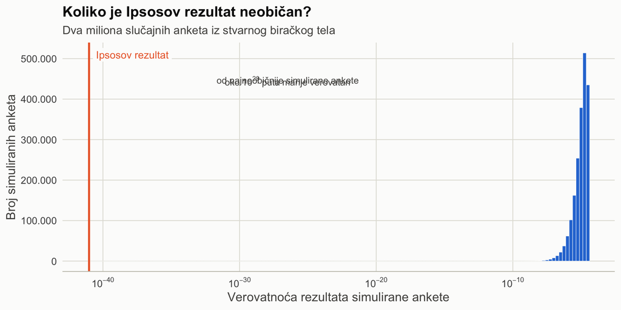

Slika 5. Koliko je svaka od dva miliona simuliranih anketa „neobična“ (što levlje, to neobičnija). Ipsosov rezultat je daleko levo od svih.

**Rezultat.** Tačna verovatnoća je **2 × 10<sup>−36</sup> (otprilike jedan u broju 5 sa 35 nula)**. Za osećaj razmere: pogoditi jednu unapred izabranu zvezdu među svih oko 10<sup>24</sup> zvezda u vidljivom svemiru događaj je verovatnoće jedan u 10<sup>24</sup>, a to je oko 10<sup>12</sup> puta *verovatnije* od Ipsosovog rezultata pod pretpostavkom slučajnog uzorka.

Do istog zaključka vodi i sama Ipsosova objavljena preciznost: Ipsos je za *Studentsku listu* naveo raspon 37,9–42,1%. Stvarni rezultat, 53,0%, bio je **10,9 poena iznad gornje granice** tog raspona, 12 puta dalje od procene nego što Ipsosova sopstvena mera greške dopušta. Raspon od 95% sme da promaši jednom u dvadeset puta, i to obično za deo poena, ne za jedanaest.

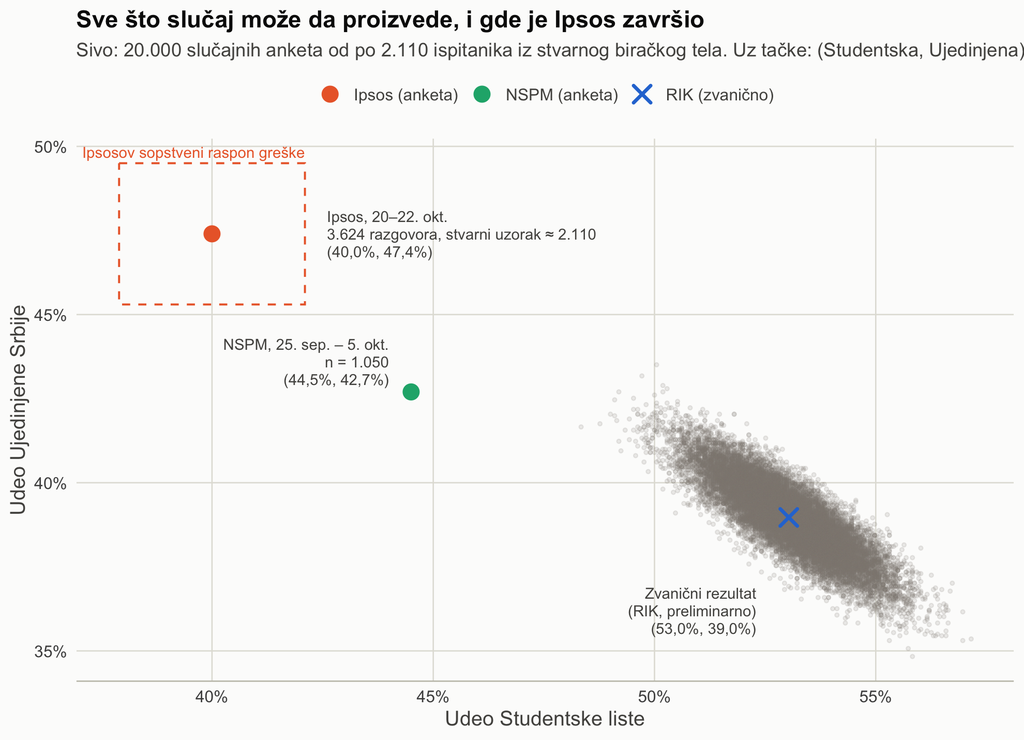

Slika 6. Gde slučajne ankete padaju (sivi oblak: 20.000 simulacija iz stvarnog biračkog tela), Ipsosov rezultat (narandžasto) sa Ipsosovim sopstvenim rasponom greške (isprekidani okvir), anketa NSPM (zeleno) i zvanični rezultat (plavi krstić).

# Da li zaključak zavisi od naših pretpostavki?

Ne. Proverili smo svaku odluku koju smo doneli:

- **Veličina uzorka.** Od namerno niskih 1.500 do svih 3.624 razgovora, verovatnoća nikad ne prelazi 10<sup>−25</sup> (Slika 7).
- **Nevažeći listići.** Ipsosovih 2,5% nevažećih je pretpostavka, ne merenje. Kad ih uklonimo iz poređenja i računamo samo važeće glasove, verovatnoća se pomera sa 10<sup>−35</sup> na 10<sup>−32</sup>: zato ovaj dokument navodi raspon, a ne jednu brojku. Zaključak se ne menja.
- **Biračko telo.** Ipsos nije anketirao Kosovo i Metohiju ni dijasporu. Kad ih uklonimo iz rezultata, udeli lista menjaju se tek u drugoj decimali.

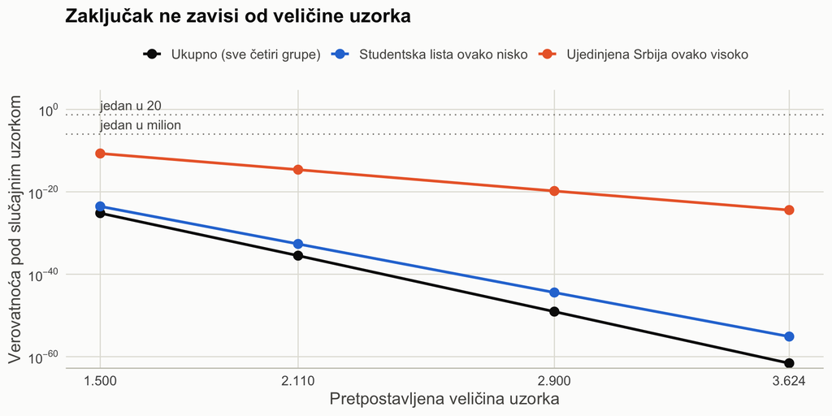

Slika 7. Verovatnoća Ipsosovog rezultata za različite pretpostavljene veličine uzorka. Sve linije su daleko ispod granice „moglo je biti slučajno“ (jedan u 20) i granice „jedan u milion“.

# Šta bi moglo da „spase“ anketu?

Umesto brojke koju niko ne može da oseti, pitamo: **koliko bi veliko moralo biti svako od „nevinih“ objašnjenja da bi Ipsosov rezultat postao običan?**

**1. Kasni preokret.** Pretpostavimo da je 22. oktobra biračko telo zaista izgledalo bliže Ipsosovoj slici, a da su se birači potom predomislili. Da bi Ipsosov rezultat bio tek obična „loša sreća“ (verovatnoća jedan u 20), oko **450.000 birača** (10,2% svih glasača) moralo bi da pređe na *Studentsku listu* u 72 sata, a *Ujedinjena Srbija* bi izgubila otprilike svakog sedmog pristalicu. Kasni pomaci od jednog do tri poena su uobičajeni; pomak ove veličine u tri dana, koliko znamo, nije zabeležen u uporedivim izborima.

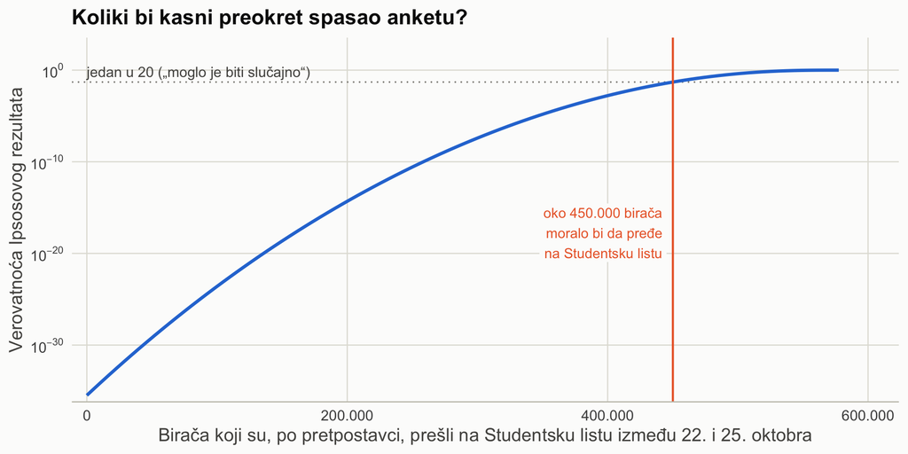

Slika 8. Kako raste verovatnoća Ipsosovog rezultata ako pretpostavimo da je sve više birača prešlo na Studentsku listu posle ankete.

**2. Izlaznost.** Ipsos je predvideo izlaznost od 64,7%; stvarna je bila 68,98%, što je oko **275.000 birača** više nego što je Ipsos očekivao. Čak i ako pretpostavimo krajnji slučaj, da je *svaki* od njih glasao za *Studentsku listu*, biračko telo koje je Ipsos pokušavao da izmeri imalo bi *Studentsku listu* na 49,9% i *Ujedinjenu Srbiju* na 41,5%: i dalje jasno vođstvo studenata, i dalje daleko od 40,0 / 47,4. Verovatnoća Ipsosovog rezultata i tada je 3 × 10<sup>−23</sup> (otprilike jedan u broju 3 sa 22 nula). A kad spojimo oba objašnjenja, krajnju izlaznost *i* kasni preokret, još uvek bi **298.000 birača** moralo da se predomisli za tri dana.

**3. Neodlučni.** Ipsosovi procenti opisuju samo ispitanike koji su imenovali listu. Ako je četvrtina birača bila neodlučna, oni bi morali da glasaju **92% za *Studentsku listu*** da bi se brojke poklopile; ako je bila petina, ne postoji nikakva podela koja to postiže. I u svakom slučaju male liste ispadnu *negativne*: pošto je Ipsos i njih precenio, nikakvo ponašanje neodlučnih ne može da pomiri celu sliku.

**4. Poređenje sa drugom anketom.** Jedina druga objavljena anketa, NSPM (terenski rad 25. septembar – 5. oktobar, 1.050 ispitanika), imala je *Studentsku listu* 44,5% i *Ujedinjenu Srbiju* 42,7%. I ona je promašila u istom smeru, ali za 8,5 poena na *Studentskoj listi*, naspram Ipsosovih 13,0, i to sa anketom završenom tri nedelje, a ne tri dana pred izbore. Ipsosov rezultat je oko **10<sup>24</sup> puta manje verovatan** od NSPM-ovog. Obična loša anketa i Ipsosova anketa nisu u istoj kategoriji.

# Zaključak

**Šta brojevi pokazuju.** Pretpostavka da su Ipsosove objavljene brojke ono što bi dao slučajan uzorak stvarnih glasača, uz slučaj kao jedini izvor greške, odbačena je svakim načinom računanja: verovatnoća je reda **2 × 10<sup>−36</sup>**, odnosno između 10<sup>−32</sup> i 10<sup>−36</sup> u zavisnosti od pristupa. Nikakav razuman izbor veličine uzorka, definicije biračkog tela ili načina računanja to ne menja. Ipsosova sopstvena objavljena preciznost vodi istom zaključku.

**Šta brojevi ne pokazuju: uzrok.** Preostala objašnjenja su: kasni preokret daleko veći od svega za šta postoje nezavisni dokazi; pomak u izlaznosti ili među neodlučnima kakav literatura ne opisuje; metodološka pristrasnost ankete (koga telefon dosegne, ko odbija ili krije nameru, način ponderisanja) znatno veća od one koju je pokazala druga anketa istih izbora; ili to da objavljene brojke ne odražavaju ono što je anketa izmerila. Moguća je i kombinacija. **Statistika sama ne može da izabere između njih**, niti između bilo kog od njih i pogrešnog izveštavanja. To što je anketu naručio jedan od učesnika izbora razlog je da se traži transparentnost, a ne dokaz namere; ovaj dokument ne iznosi nikakvu tvrdnju o namerama. Razrešenje zahteva ono što proračun ne može da pruži: Ipsosove sirove podatke, shemu ponderisanja i postupanje sa neodlučnima.

**Napomene.** Rezultati RIK-a su preliminarni (8.339 od 8.392 biračkih mesta) i ovde se uzimaju kao istina; preostalih 0,6% biračkih mesta ne može pomeriti udele za više od nekoliko desetih delova poena. Veličina uzorka od 2.110 izvedena je iz Ipsosovih objavljenih raspona greške, a ne iz Ipsosove izjave. Ovo je sažetak. Potpuna analiza, sa svim formulama, kodom, proverama i izvorima, nalazi se u tehničkom izveštaju na engleskom jeziku: *Could Ipsos Have Obtained Its Numbers by Chance?*. Tehnički izveštaj postoji u dve verzije, u programskim jezicima R i Python (Ipsos-Izbori-2026-py.html), sa istim tekstom i istim koracima. Glavni broj, 2 × 10<sup>−36</sup>, i svi ostali tačni rezultati dobijeni su bez ikakve slučajnosti i do poslednje cifre su isti u obe verzije. Brojke koje potiču iz simulacija (recimo najekstremnija od 100.000 simuliranih anketa na Slici 3) malo se razlikuju između dve verzije, jer R i Python koriste različite generatore slučajnih brojeva; te razlike su veličine „šuma“ simulacije i ne utiču ni na jedan zaključak. Ovaj sažetak preuzima simulacione brojke iz R verzije. Sva tri dokumenta, sa izvornim kodom, dostupna su na [GitHubu](https://github.com/GoranMilovanovic/izboriRepublikaSrbija_20261025).

*Izvori:* Ipsos Strategic Marketing, [saopštenje od 22. oktobra 2026](https://www.ipsos.com/sr-rs/rezultati-istrazivanja-pred-parlamentarne-izbore-oktobar-2026) · Republička izborna komisija, [portal rezultata](https://www.rik.parlament.gov.rs/542645/rezultati/), očitano 31. oktobar 2026, 11:00 · NSPM, [Srbija, jesen 2026 (I)](https://www.nspm.rs/istrazivanja-javnog-mnjenja/srbija-jesen-2026.-i.html).